# 10_Minutes_Project_LX

#### 1.2.3 Method Comparison

- I compared the percent loss of data. If I dropped all NA data, 98% of data information will be missing.
- If I dropped two columns and remove rows with NA data, only 27% of data will be missing. Thus it is a good idea to choose the second method to deal with missing data.

```r
salary_no_missing <- na.omit(salary1)
PercentLossOfData <- (nrow(salary1) - nrow(salary_no_missing))*100/nrow(salary1)
PercentLossOfData
```

```
## [1] 98.75367
```

```r
salary_witout_most_missing <- salary1 # Create a copy
salary_witout_most_missing$Easy.Apply <- NULL # Remove NonD variable.
salary_witout_most_missing$Competitors <- NULL # Remove Dream variable.
salary_witout_most_missing <- na.omit(salary_witout_most_missing)
PercentLossOfData <- (nrow(salary1) - nrow(salary_witout_most_missing))*100/nrow(salary1)
PercentLossOfData
```

```
## [1] 27.07722
```

### 1.3 Data Re-code

- Since the data are very dirty. I need to re-code my data for better analysis.

#### 1.3.1 Salary Re-code

- Salary here are a range. I separated it to low salary and high salary. I calculated the mean of low salary and high salary as my average salary data.
- Salary were in character type, I converted it to numeric type.

```r
salary2 <- salary_witout_most_missing
salary2<- separate(salary2, col=Salary.Estimate, into=c('Low_Salary','High_Salary' ), sep='-')
salary3<- separate(salary2, col=High_Salary, into=c('High_Salary','String' ), sep=' ')
salary3$String <- NULL
```

```r
library(tidyverse)
salary3$High_Salary<-gsub("K","",as.character(salary3$High_Salary))
salary3$High_Salary<-gsub("\\$","",as.character(salary3$High_Salary))
salary3$Low_Salary<-gsub("K","",as.character(salary3$Low_Salary))
salary3$Low_Salary<-gsub("\\$","",as.character(salary3$Low_Salary))
salary3$AvgSalary <- ((as.numeric(salary3$High_Salary) + as.numeric(salary3$Low_Salary))/2)
#head(salary3)
salary3$Low_Salary <- NULL
salary3$High_Salary <- NULL
```

#### 1.3.2 Company and Rating Re-code

- Since the company name are combined with rating, I separated it.

```r
summary(salary$Rating)
```

```
##    Min. 1st Qu.  Median    Mean 3rd Qu.    Max.
##  -1.000   3.200   3.700   3.346   4.100   5.000
```

```r
salary4<- separate(salary3, col=Company.Name, into=c('Company','Star' ), sep='\n')
summary(as.numeric(salary4$Star))
```

```
##    Min. 1st Qu.  Median    Mean 3rd Qu.    Max.
##   1.700   3.400   3.700   3.772   4.100   5.000
```

```r
salary4$Rating <- NULL # Since Rating has negative values, I choose Star as my analysis part
```

#### 1.3.3 Location Re-code

- Location are combined with City and state. To support my analysis better, I split it into city and state.

```r
salary5<- separate(salary4, col=Location, into=c('City','state' ), sep=",")
```

#### 1.3.4 Founded Year Re-code

```r
# Want to Recode the founded year as number of years history
salary5$Founded <- (2022 - salary5$Founded)
```

## 2. Factors Analytics and Visulzaition

### 2.1 Salary and Company Rating

- As an employee, the most important thing are salary and company rating(which is related to working environment). Thus, I choose two variables to be my core analytics points.

#### 2.1.1 Salary and Rating distribution

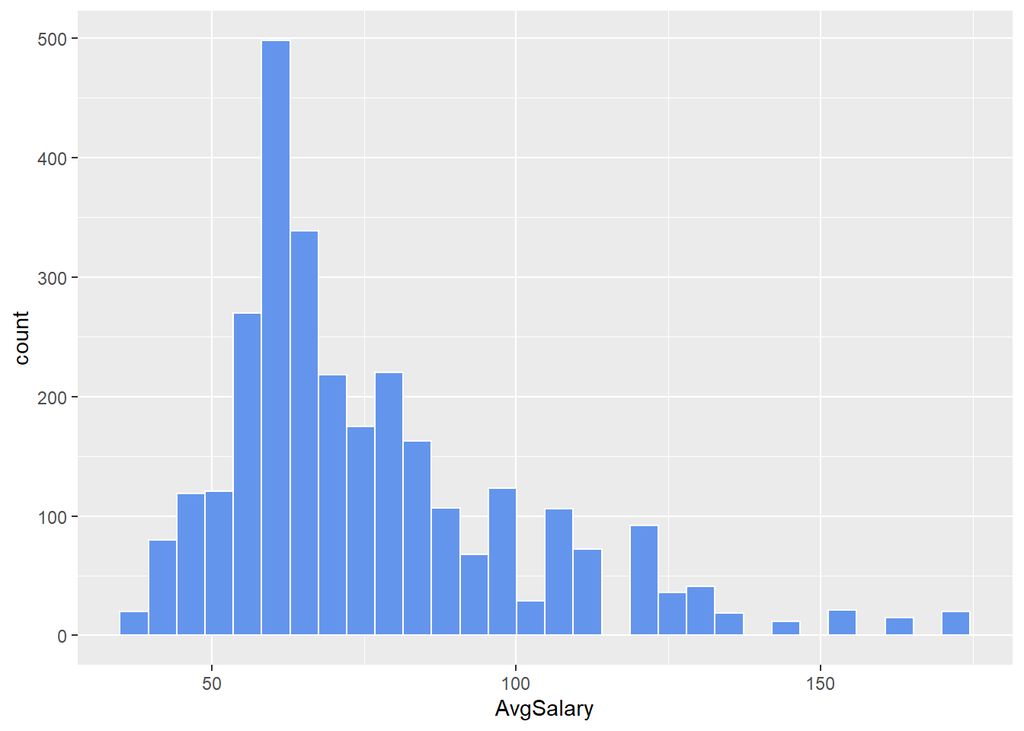

```r
Salary <- salary5
ggplot(data = Salary) + geom_histogram(mapping = aes(x = AvgSalary),color="white", fill="cornflowerblue")
```

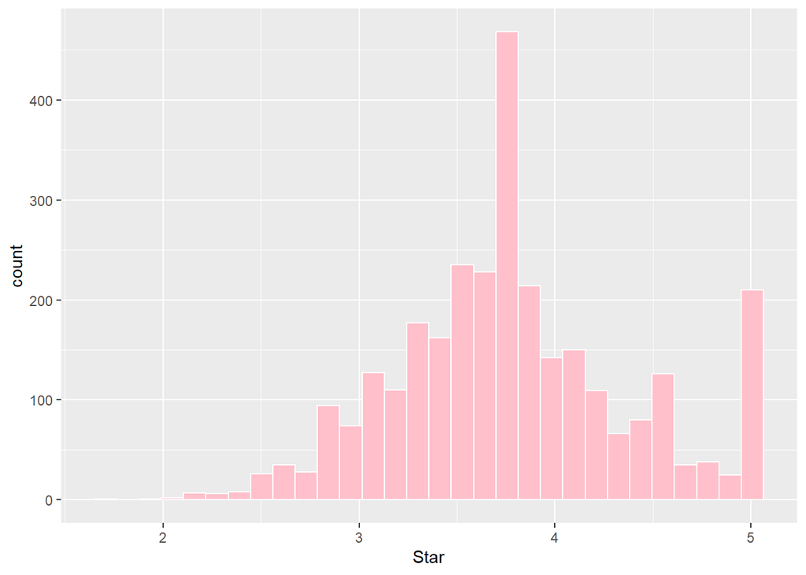

```r
Salary$Star <- as.numeric(Salary$Star)
ggplot(data = Salary) + geom_histogram(mapping = aes(x = Star),color="white", fill="pink")
```

```r
mean(Salary$AvgSalary)
```

```
## [1] 76.16454
```

```r
mean.default(Salary$Star,na.rm=TRUE)
```

```
## [1] 3.772151
```

#### 2.1.2 Salary related with company rating

- When looked into the relationship between salary and rating, it is interesting to found that salary does not always have a positive relationship with rating.
- However, when just focused on the rating between (2.5-4.5), it displays a positive connection: higher the salary, and higher the company rating

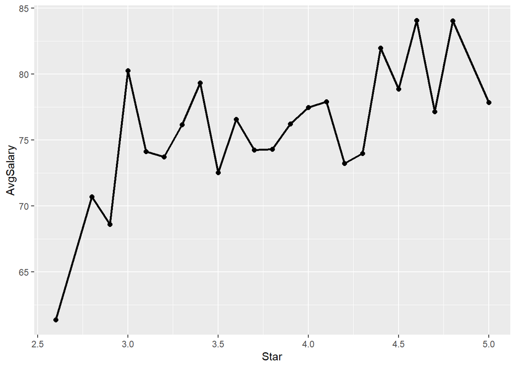

```r
Salary$Star <- as.numeric(Salary$Star)
Salary9<-Salary %>% group_by(Star) %>% summarise_if(is.numeric, mean, na.rm=TRUE)
Salary9$count <- (Salary %>% count(Star))$n
Salary9<- Salary9 %>% filter(count >= 30)
ggplot(data = Salary9, aes(x = Star, y = AvgSalary,group=1)) +geom_line(size = 1)+geom_point(color="black",size =2)
```

### 2.2 Salary and Location Analytics

#### 2.2.1 State and Salary

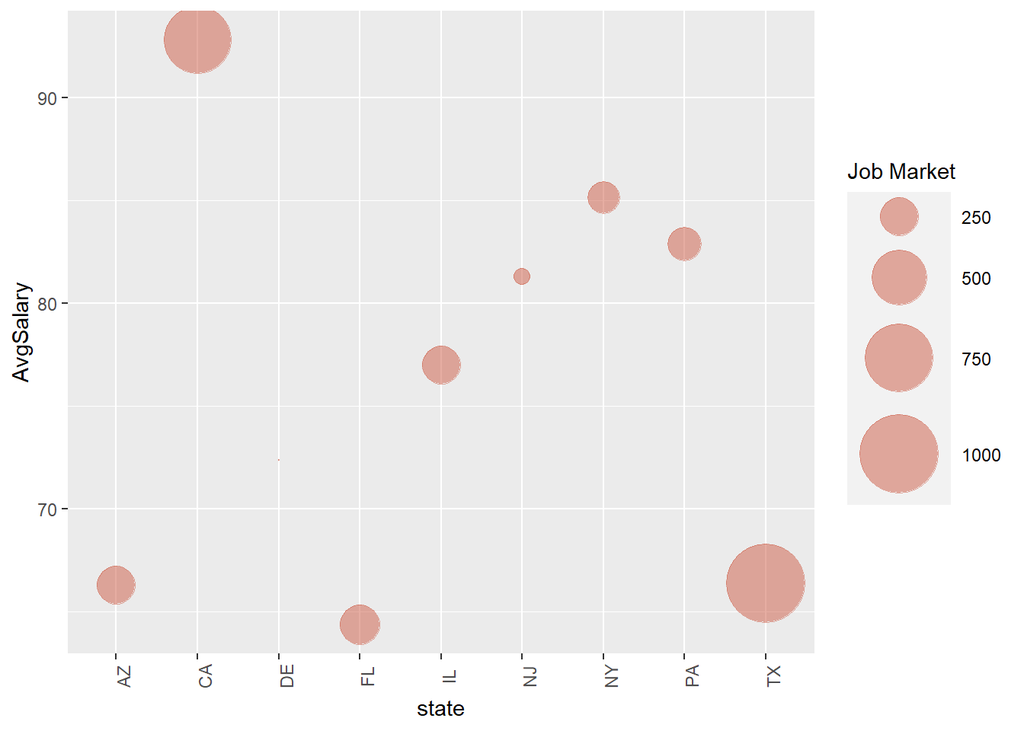

```r
salary6 <- Salary %>%group_by(state) %>%summarise_if(is.numeric, mean, na.rm=TRUE)
salary6$count <- (Salary %>% count(state))$n
#head(salary6)
salary6 %>% ggplot(aes(x=state, y=AvgSalary, size = count)) +geom_point(alpha=0.5,color="coral3") +scale_size(range = c(.01, 18), name="Job Market")+theme(axis.text.x = element_text(angle=90))
```

#### 2.2.2 City and Salary

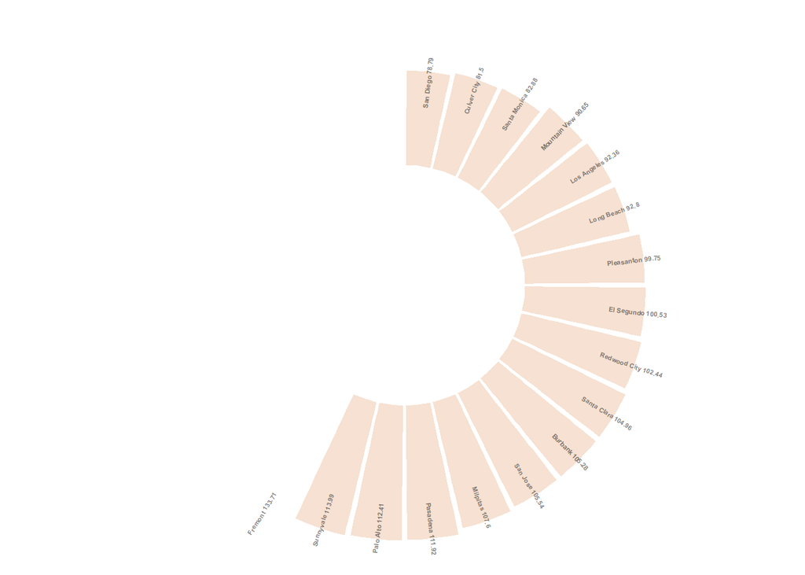

```r
salary7<- Salary %>% filter(state == " CA")

salary8 <- salary7 %>%group_by(City) %>%summarise_if(is.numeric, mean, na.rm=TRUE)
salary8$count <- (salary7 %>% count(City))$n
# only choose city where the job chances >=5
salary8<- salary8 %>% filter(count >= 5)
salary8<- salary8[order(salary8$AvgSalary), ]
salary8$City <- paste(salary8$City,round(salary8$AvgSalary, digits=2))
empty_bar <- 11

# Add lines to the initial dataset
to_add <- matrix(NA, empty_bar, ncol(salary8))
colnames(to_add) <- colnames(salary8)
salary8 <- rbind(salary8, to_add)
salary8$id <- seq(1, nrow(salary8))

# Get the name and the y position of each label
label_data <- salary8
number_of_bar <- nrow(label_data)
angle <- 90 - 360 * (label_data$id-0.5) /number_of_bar     # I substract 0.5 because the letter must have the angle of the center of the bars. Not extreme right(1) or extreme left (0)
label_data$hjust <- ifelse( angle < -90, 1, 0)
label_data$angle <- ifelse(angle < -90, angle+180, angle)

# Make the plot
p <- ggplot(salary8, aes(x=as.factor(id), y=AvgSalary)) +       # Note that id is a factor. If x is numeric, there is some space between the first bar
  geom_bar(stat="identity", fill=alpha("chocolate", 0.2)) +
  ylim(-100,120) +
  theme_minimal() +
  theme(
    axis.text = element_blank(),
    axis.title = element_blank(),
    panel.grid = element_blank(),
    plot.margin = unit(rep(-1,4), "cm")
  ) +
  coord_polar(start = 0) +
  geom_text(data=label_data, aes(x=id, y=AvgSalary-30, label=City, hjust=hjust), color="black", fontface="bold",alpha=0.5, size=1.5, angle= label_data$angle, inherit.aes = FALSE )

p
```

### 2.3 Salary and Company Size Analytics

#### 2.3.1 Company Size with Salary

```r
unique(Salary$Size)
```

```
## [1] 10000+ employees        501 to 1000 employees   201 to 500 employees
## [4] 1001 to 5000 employees  1 to 50 employees       51 to 200 employees
## [7] 5001 to 10000 employees Unknown
## 9 Levels: -1 1 to 50 employees 10000+ employees ... Unknown
```

- There is no significant correlation between company size and salary. Given this, the average wage does not differ significantly depending on the size of the organization.

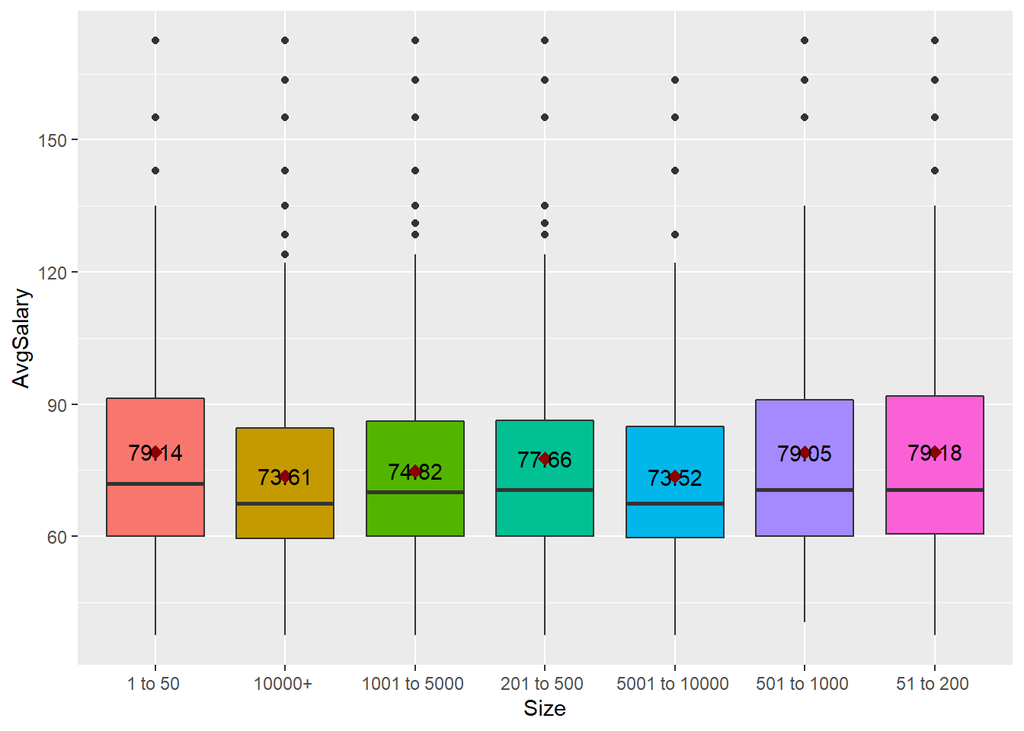

```r
salary10 <- Salary %>% filter(Size != "Unknown")
salary10$Size <-gsub("employees","",as.character(salary10$Size))
means <- aggregate(AvgSalary ~  Size, salary10, mean)
means$AvgSalary <- round(means$AvgSalary, digits=2)
salary10 %>% mutate(class = fct_reorder(Size, AvgSalary,.fun='mean')) %>%ggplot(aes(x = Size, y = AvgSalary, fill = Size)) + geom_boxplot() +theme(legend.position="none")+  stat_summary(fun=mean, colour="darkred", geom="point", shape=18, size=3, show.legend=FALSE) + geom_text(data = means, aes(label = AvgSalary, y = AvgSalary))
```

### 2.4 Founded year Analytics

#### 2.4.1 Founded year and Salary

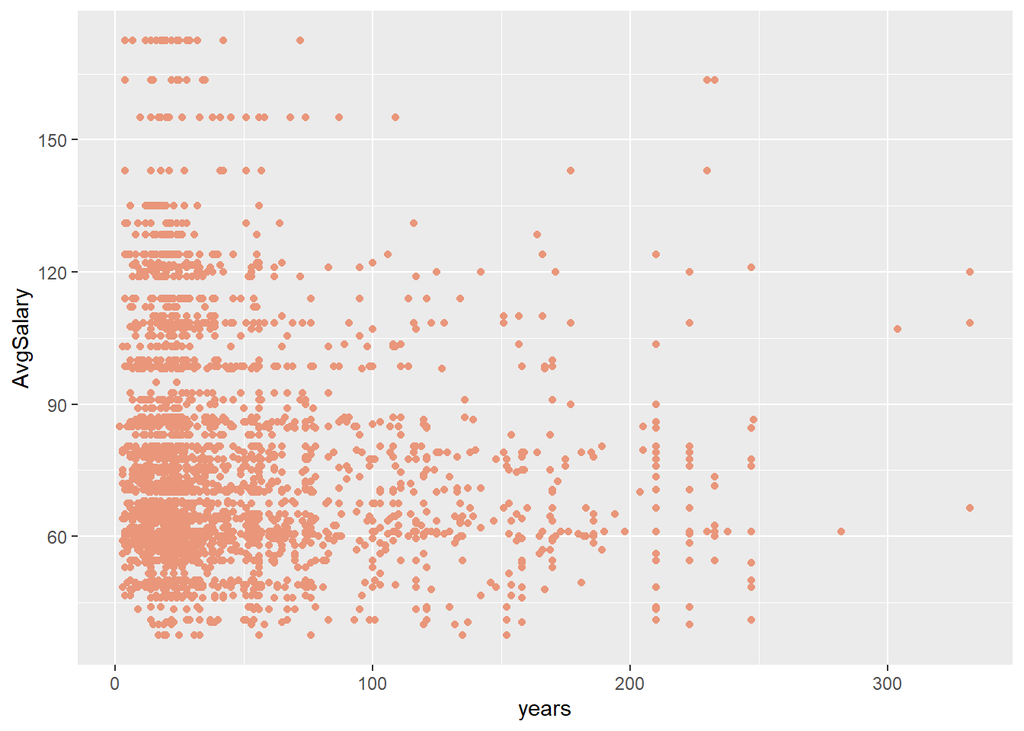

```r
par(mfcol = c(2, 2))
Salary$Founded <- as.numeric(Salary$Founded)
ggplot(data = Salary) + geom_point(mapping = aes(y = AvgSalary, x = Founded),color= "darksalmon") +labs(x = "years", y = "AvgSalary")
```

### 2.5 Sector Analytics

#### 2.5.1 Sector with Salary and Rating

- The majority of data scientist jobs are in the business services and IT sectors.

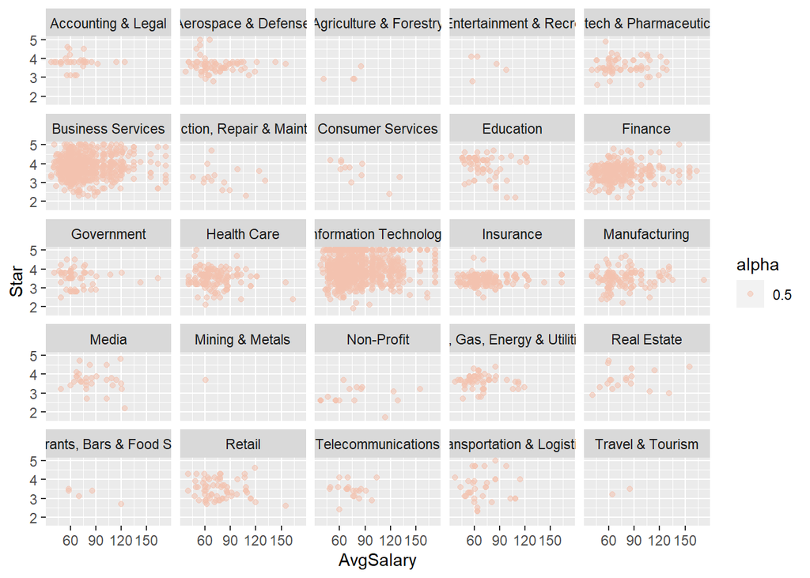

```r
ggplot(data = Salary) + geom_point(mapping = aes(x = AvgSalary, y = Star, alpha = 0.5), color = "#F3C2AF") + facet_wrap(~ Sector)
```

#### 2.5.2 Sector with Salary

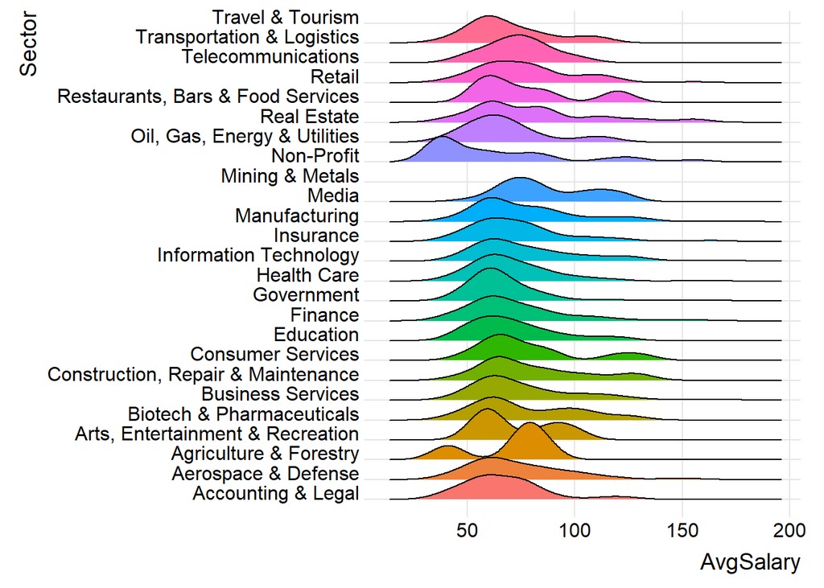

```r
library(ggridges)
ggplot(Salary, aes(x = AvgSalary, y = Sector, fill = Sector)) +
  geom_density_ridges() +
  theme_ridges() +
  theme(legend.position = "none")
```

### 2.6 Salary and Type.of.ownership

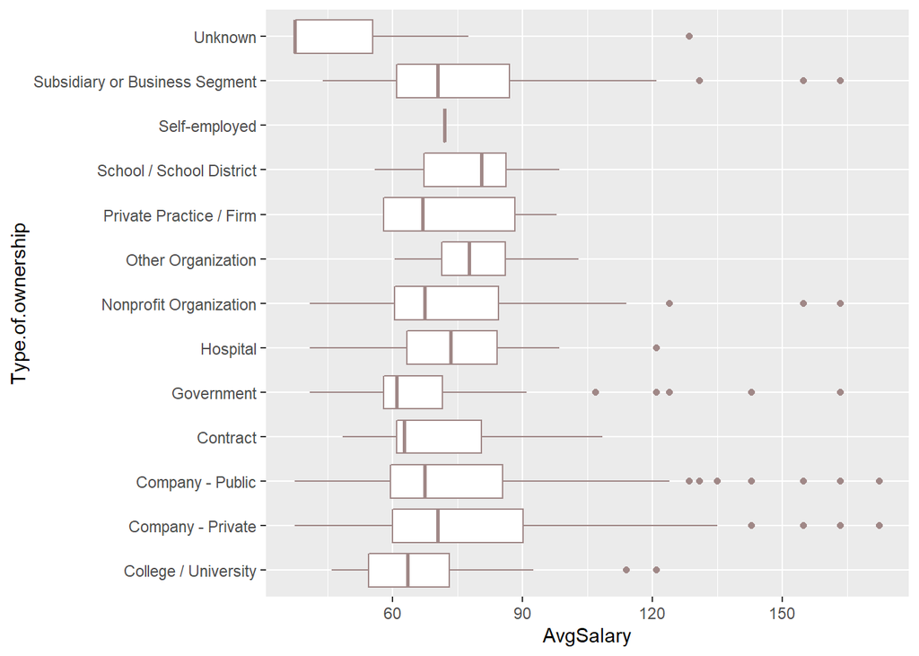

```r
ggplot(data = Salary, mapping = aes(x = Type.of.ownership, y = AvgSalary)) + geom_boxplot(color= "#A08887") + coord_flip()+theme(legend.position="none") +
    scale_fill_brewer("Blues")
```

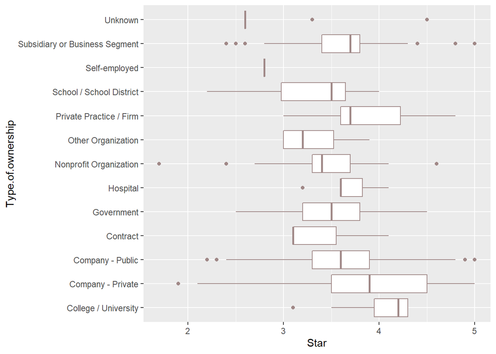

```r
ggplot(data = Salary, mapping = aes(x = Type.of.ownership, y = Star)) + geom_boxplot(color= "#A08887") + coord_flip()+theme(legend.position="none") +
    scale_fill_brewer("Blues")
```

### 2.7 Education Analytics

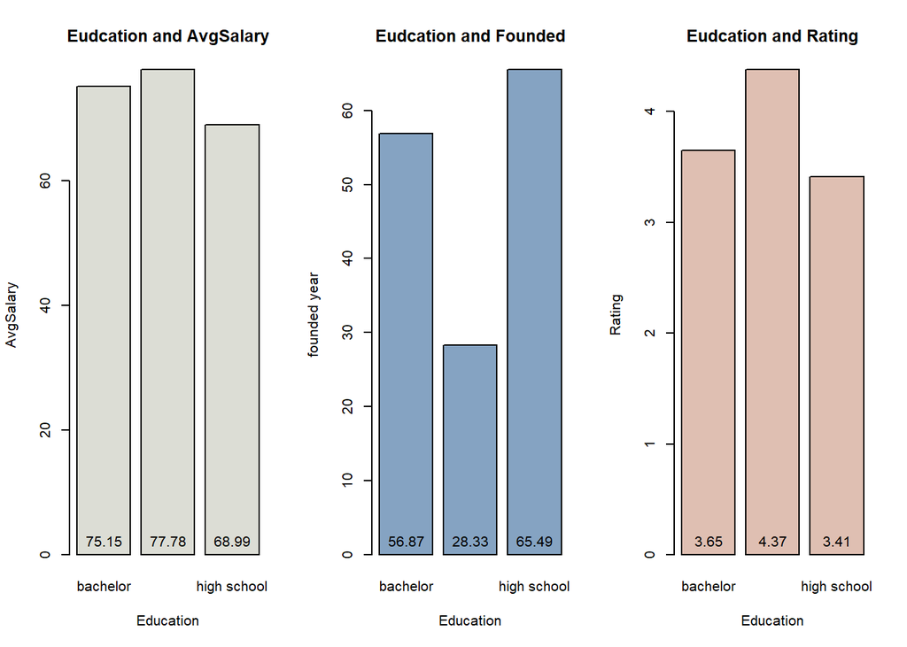

```r
salary11 <- Salary %>%group_by(education) %>%summarise_if(is.numeric, mean, na.rm=TRUE)
salary11$count <- (Salary %>% count(education))$n
salary11 <- salary11[-4,]

#head(salary11)
par(mfcol = c(1, 3))
p1 <- barplot(height =salary11$AvgSalary, names = salary11$education, xlab="Education", ylab="AvgSalary", main="Eudcation and AvgSalary", col="#DCDDD5")
text(p1, 0, round(salary11$AvgSalary, 2),cex=1,pos=3)

p2 <- barplot(height =salary11$Founded, names = salary11$education, xlab="Education", ylab="founded year", main="Eudcation and Founded", col=rgb(0.2,0.4,0.6,0.6))
text(p2, 0, round(salary11$Founded, 2),cex=1,pos=3)

p3 <- barplot(height =salary11$Star, names = salary11$education, xlab="Education", ylab="Rating", main="Eudcation and Rating", col="#DFBFB2")
text(p3, 0, round(salary11$Star, 2),cex=1,pos=3)
```

## 3. Regression Model Building

```r
dummy_df <-dummy_cols(Salary, select_columns=c('Sector','Size','state','Type.of.ownership',"eduction"), remove_selected_columns = TRUE)
#colnames(dummy_df)
```

```r
#summary(df)
#remove zeros of columns
dummy_df_cal <- dummy_df[,c(11:69)]
ifelse(colSums(dummy_df_cal) > 5, colSums(dummy_df_cal), NA)
```

```
##                                        Sector_-1
##                                               NA
##                        Sector_Accounting & Legal
##                                               31
##                       Sector_Aerospace & Defense
##                                               70
##                    Sector_Agriculture & Forestry
##                                               NA
##          Sector_Arts, Entertainment & Recreation
##                                               NA
##                 Sector_Biotech & Pharmaceuticals
##                                               60
##                         Sector_Business Services
##                                              697
##        Sector_Construction, Repair & Maintenance
##                                               15
##                         Sector_Consumer Services
##                                               11
##                                 Sector_Education
##                                               61
##                                   Sector_Finance
##                                              316
##                                Sector_Government
##                                               61
##                               Sector_Health Care
##                                              144
##                    Sector_Information Technology
##                                              963
##                                 Sector_Insurance
##                                              171
##                             Sector_Manufacturing
##                                              120
##                                     Sector_Media
##                                               30
##                           Sector_Mining & Metals
##                                               NA
##                                Sector_Non-Profit
##                                               26
##              Sector_Oil, Gas, Energy & Utilities
##                                               55
```

[output cut: 63 more lines]

```
##                                               18
##         Type.of.ownership_Nonprofit Organization
##                                              101
##             Type.of.ownership_Other Organization
##                                               NA
##        Type.of.ownership_Private Practice / Firm
##                                                8
##       Type.of.ownership_School / School District
##                                                6
##                  Type.of.ownership_Self-employed
##                                               NA
## Type.of.ownership_Subsidiary or Business Segment
##                                              135
##                        Type.of.ownership_Unknown
##                                               19
```

```r
drop <- c("Size_-1","Sector_-1","Type.of.ownership_-1","Type.of.ownership_Self-employed","Type.of.ownership_Franchise","Sector_Mining & Metals","Job.Title","Low_Salary","High_Salary","Revenue","Company","Headquarters","Industry","City","Size_Unknown","Unknown","education_Unknown","Sector_Agriculture & Forestry","education")
df = dummy_df[,!(names(dummy_df) %in% drop)]
#colnames(df)
```

```r
names(df) <- gsub('Type.of.ownership_','',names(df))
names(df) <- gsub('state_ ','',names(df))
names(df) <- gsub('_','',names(df))
names(df) <- gsub('/','',names(df))
names(df) <- gsub('&','',names(df))
names(df) <- gsub(',','',names(df))
names(df) <- gsub(' ','',names(df))
names(df) <- gsub('-','',names(df))
colnames(df)[28] <- "SizeOver10000employees"
#colnames(df)
```

```r
#remove high corelated variables

drop = findCorrelation(abs(cor(df)), cutoff = .5)
drop = names(df)[drop]
drop
```

```
## [1] "CompanyPrivate"  "CompanyPublic"   "Government"      "SectorEducation"
## [5] "SectorNonProfit"
```

```r
df =df %>%subset(select=-c(CompanyPrivate, CompanyPublic ,Government, SectorEducation, SectorNonProfit))
```

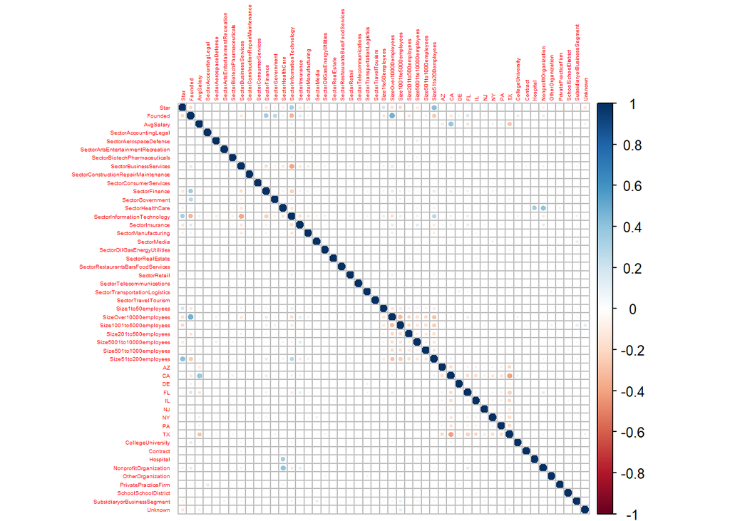

```r
corrplot(cor(df), tl.cex = 0.3)
```

- Split the model to train and test dataset

```r
set.seed(123, sample.kind = "Rejection")
spl = sample(nrow(df),0.8*nrow(df))
#head(spl)
```

```r
# Now lets split our dataset into train and test:
train_df = df[spl,]
test_df = df[-spl,]
ncol(train_df)
```

```
## [1] 49
```

```r
ncol(test_df)
```

```
## [1] 49
```

### 3.1 Simple Regression Model

#### 3.1.1 Subset Selection

```r
library(leaps)
library(ISLR)
fullfit=regsubsets(AvgSalary ~., train_df, nvmax = 10, really.big=T)
```

```
## Reordering variables and trying again:
```

```r
selsummary <- summary(fullfit)
names(selsummary)
```

```
## [1] "which"  "rsq"    "rss"    "adjr2"  "cp"     "bic"    "outmat" "obj"
```

```r
selsummary$rsq
```

```
##  [1] 0.1465941 0.1704884 0.1960919 0.2108068 0.2168622 0.2222187 0.2253953
##  [8] 0.2275135 0.2289754 0.2302240 0.2311958
```

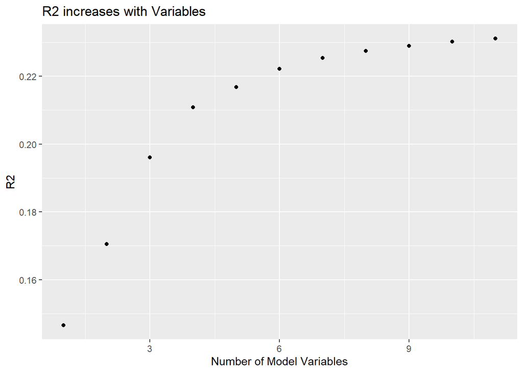

```r
#R-Square Plot
rquare <- as.data.frame(selsummary$rsq)
names(rquare)<-"R2"
# Plot
ggplot(rquare, aes(x = c(1:nrow(rquare)), y = R2)) +
  geom_point()+
  labs(x="Number of Model Variables")+
  labs(title="R2 increases with Variables")
```

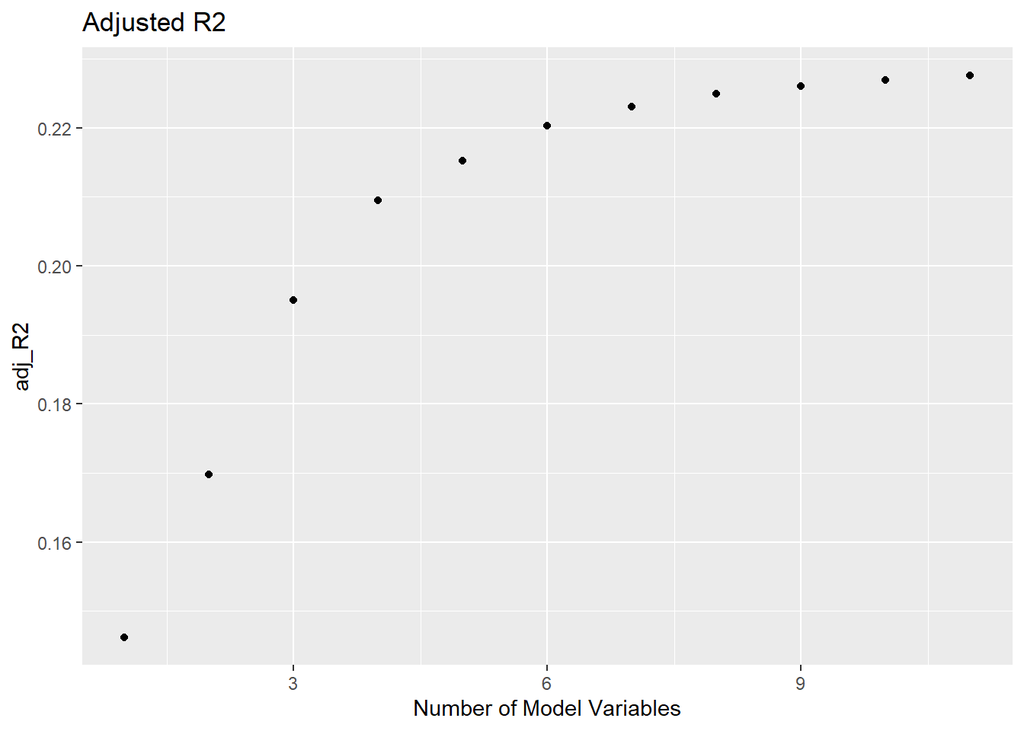

```r
#Adj R-Square Plot
adjrsquare <- as.data.frame(selsummary$adjr2)
names(adjrsquare)<-"adj_R2"
ggplot(adjrsquare, aes(x = c(1:nrow(adjrsquare)), y = adj_R2)) +
  geom_point()+
  labs(x="Number of Model Variables")+
  labs(title="Adjusted R2")
```

```r
which(max(adjrsquare)==adjrsquare)
```

```
## [1] 11
```

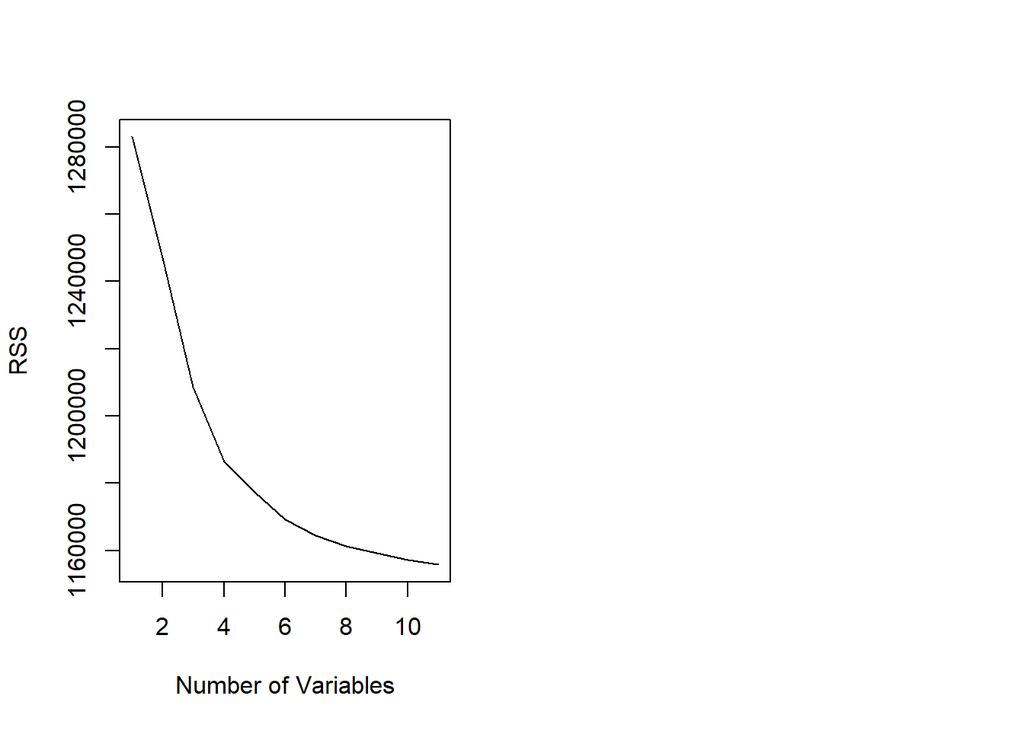

```r
par(mfrow=c(1,2))
plot(selsummary$rss,xlab="Number of Variables",ylab="RSS",type="l")
```

```
## [1] 11
```

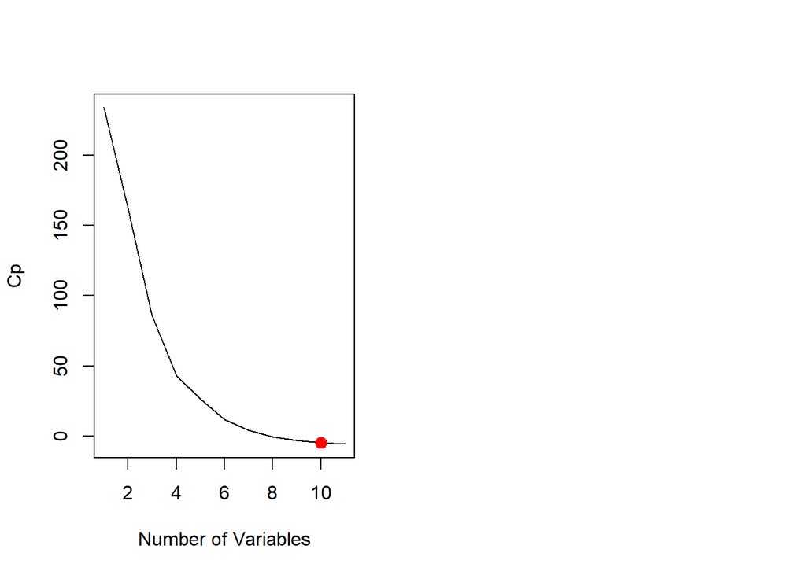

```r
par(mfrow=c(1,2))
plot(selsummary$cp,xlab="Number of Variables",ylab="Cp",type='l')
points(10,selsummary$cp[10],col="red",cex=2,pch=20)
which.min(selsummary$cp)
```

```r
# Using BIC (Bayesian information criterion): Choose the minimum
which.min(selsummary$bic)
```

```
## [1] 7
```

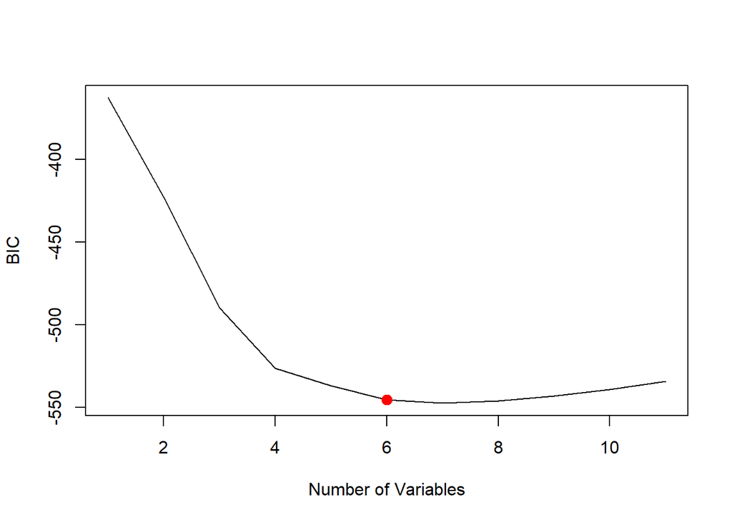

```r
plot(selsummary$bic,xlab="Number of Variables",ylab="BIC",type='l')
points(6,selsummary$bic[6],col="red",cex=2,pch=20)
```

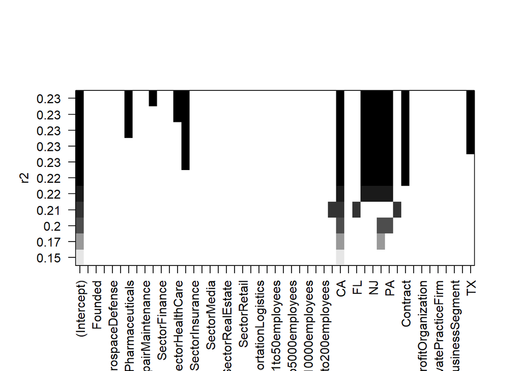

```r
plot(fullfit,scale="r2")
```

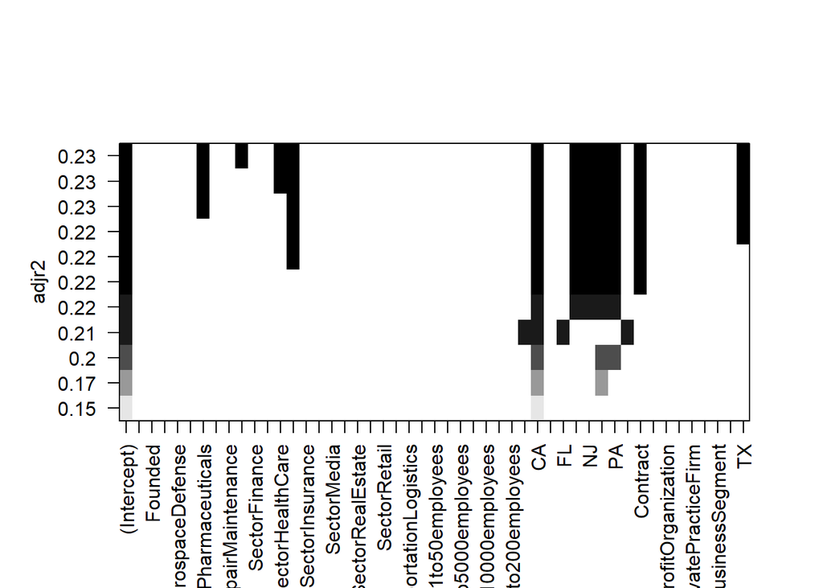

```r
plot(fullfit,scale="adjr2")
```

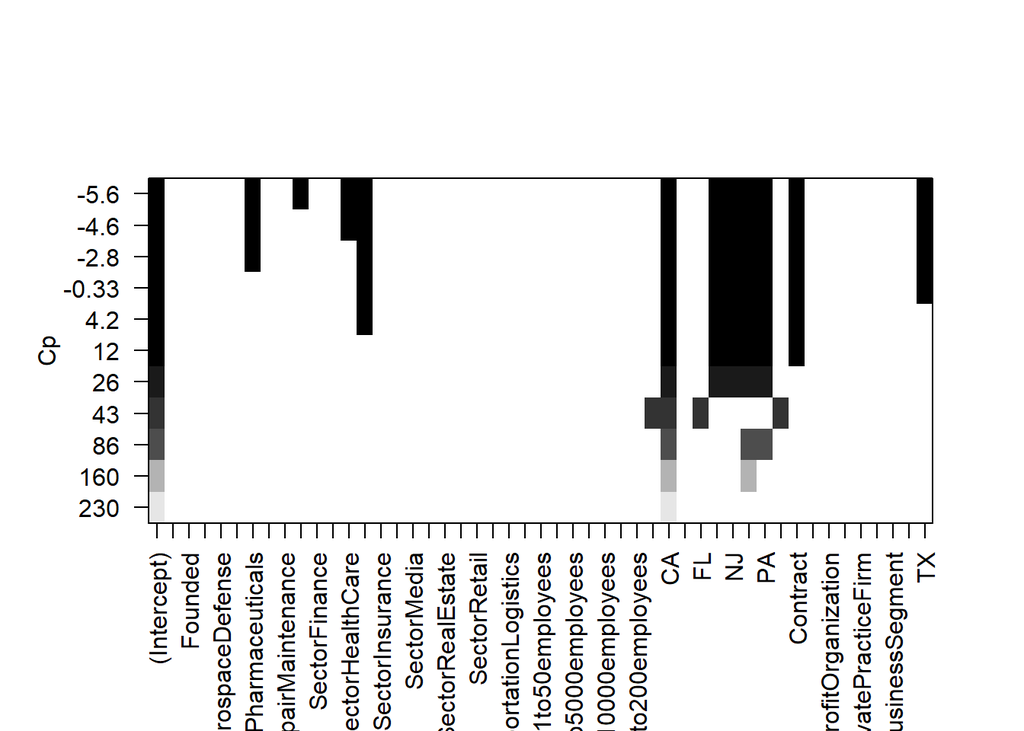

```r
plot(fullfit,scale="Cp")
```

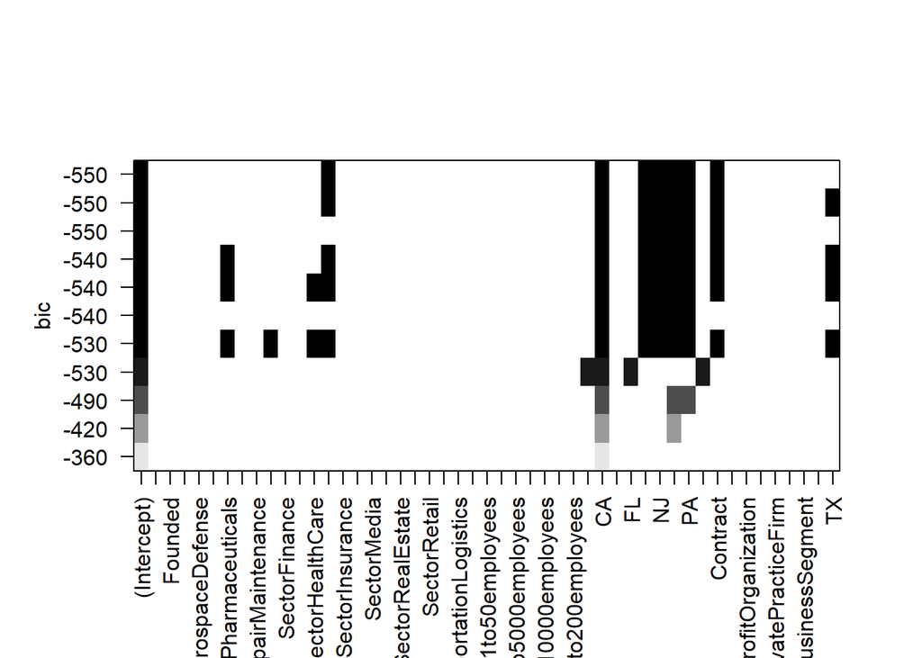

```r
plot(fullfit,scale="bic")
```

```r
coef(fullfit,10)
```

```
##                  (Intercept) SectorBiotechPharmaceuticals
##                   65.2454386                   -6.5407561
##             SectorHealthCare  SectorInformationTechnology
##                   -3.9846623                    2.7949666
##                           CA                           IL
##                   27.6807646                   11.3107761
##                           NJ                           NY
##                   16.2107766                   19.9502400
##                           PA                     Contract
##                   18.1346353                   -6.3259544
##                           TX
##                    0.2906078
```

```r
coef(fullfit,11)
```

```
##                  (Intercept) SectorBiotechPharmaceuticals
##                   65.2732538                   -6.6365872
##       SectorConsumerServices             SectorHealthCare
##                  -12.3228593                   -4.0634589
##  SectorInformationTechnology                           CA
##                    2.7084989                   27.8055830
##                           IL                           NJ
##                   11.3124657                   16.2167909
##                           NY                           PA
##                   20.2024165                   18.1452437
##                     Contract                           TX
##                   -6.4323219                    0.3112853
```

```r
fullsum <- summary(fullfit)
min(fullsum$cp)
```

```
## [1] -5.619059
```

#### 3.1.2 Model Building

```r
fit <- lm(AvgSalary ~SectorBiotechPharmaceuticals+SectorInformationTechnology+SectorHealthCare+ CA + IL+ PA + Contract +TX+NJ+NY , data=train_df)
summary(fit)
```

```
##
## Call:
## lm(formula = AvgSalary ~ SectorBiotechPharmaceuticals + SectorInformationTechnology +
##     SectorHealthCare + CA + IL + PA + Contract + TX + NJ + NY,
##     data = train_df)
##
## Residuals:
##     Min      1Q  Median      3Q     Max
## -49.721 -14.973  -4.245  11.964  84.105
##
## Coefficients:
##                              Estimate Std. Error t value Pr(>|t|)
## (Intercept)                   65.2454     1.0938  59.651  < 2e-16 ***
## SectorBiotechPharmaceuticals  -6.5408     3.1875  -2.052   0.0403 *
## SectorInformationTechnology    2.7950     0.9924   2.816   0.0049 **
## SectorHealthCare              -3.9847     2.1337  -1.867   0.0620 .
## CA                            27.6808     1.4175  19.529  < 2e-16 ***
## IL                            11.3108     1.8974   5.961 2.88e-09 ***
## PA                            18.1346     2.0104   9.020  < 2e-16 ***
## Contract                      -6.3260    11.1151  -0.569   0.5693
## TX                             0.2906     1.3102   0.222   0.8245
## NJ                            16.2108     3.2553   4.980 6.82e-07 ***
## NY                            19.9502     2.1061   9.473  < 2e-16 ***
## ---
## Signif. codes:  0 '***' 0.001 '**' 0.01 '*' 0.05 '.' 0.1 ' ' 1
##
## Residual standard error: 22.17 on 2376 degrees of freedom
## Multiple R-squared:  0.2233, Adjusted R-squared:   0.22
## F-statistic: 68.29 on 10 and 2376 DF,  p-value: < 2.2e-16
```

#### 3.1.2 Model Building

```r
mean_train = mean(train_df$AvgSalary)
test_pred = predict(fit, newdata = test_df)
SSE_lin = sum((test_df$AvgSalary  - test_pred)^2)
SST_lin = sum((test_df$AvgSalary - mean_train)^2)
R_square= 1 - SSE_lin/SST_lin
print(paste("Linear_Regression has a R-squred of", round(R_square,4)))
```

```
## [1] "Linear_Regression has a R-squred of 0.1726"
```

### 3.2 Regression Tree Model

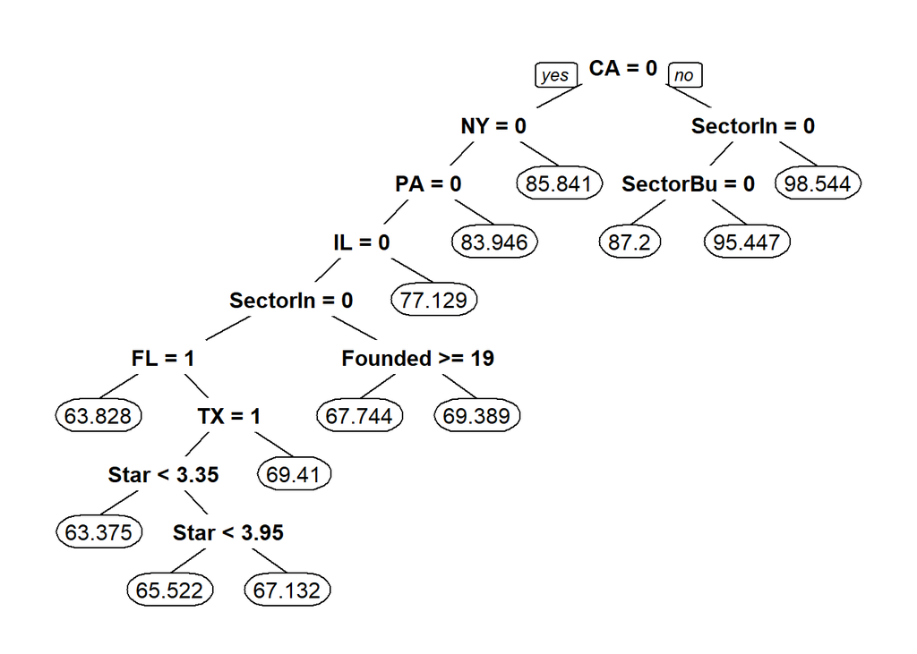

```r
treea <- rpart (AvgSalary ~ .-Unknown, data= train_df, method='anova', minbucket=100, cp=0.00001)
prp(treea,digits = -5)
```

```r
printcp(treea)
```

```
##
## Regression tree:
## rpart(formula = AvgSalary ~ . - Unknown, data = train_df, method = "anova",
##     minbucket = 100, cp = 1e-05)
##
## Variables actually used in tree construction:
##  [1] CA                          FL
##  [3] Founded                     IL
##  [5] NY                          PA
##  [7] SectorBusinessServices      SectorInformationTechnology
##  [9] Star                        TX
##
## Root node error: 1503414/2387 = 629.83
##
## n= 2387
##
##            CP nsplit rel error  xerror     xstd
## 1  0.14659411      0   1.00000 1.00073 0.040234
## 2  0.02474890      1   0.85341 0.85630 0.034163
## 3  0.01259351      3   0.80391 0.81011 0.030354
## 4  0.00628692      4   0.79131 0.79810 0.030317
## 5  0.00352089      5   0.78503 0.79520 0.030277
## 6  0.00135874      6   0.78151 0.79197 0.030065
## 7  0.00109621      7   0.78015 0.79063 0.029895
## 8  0.00051323      9   0.77796 0.78965 0.029876
## 9  0.00017745     10   0.77744 0.78909 0.029824
## 10 0.00014061     11   0.77726 0.78984 0.029825
## 11 0.00001000     12   0.77712 0.79002 0.029827
```

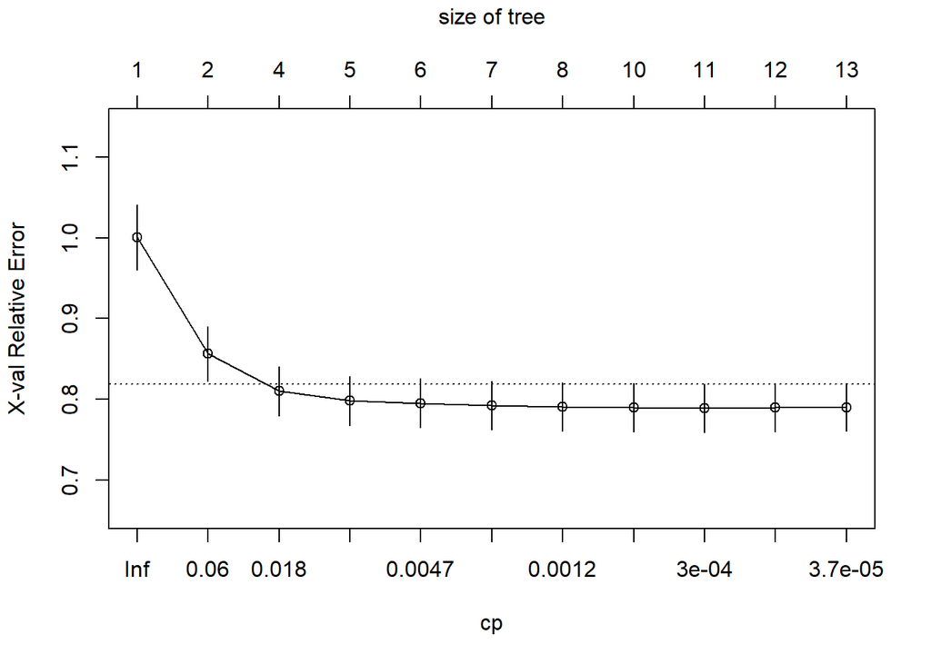

```r
plotcp(treea)
```

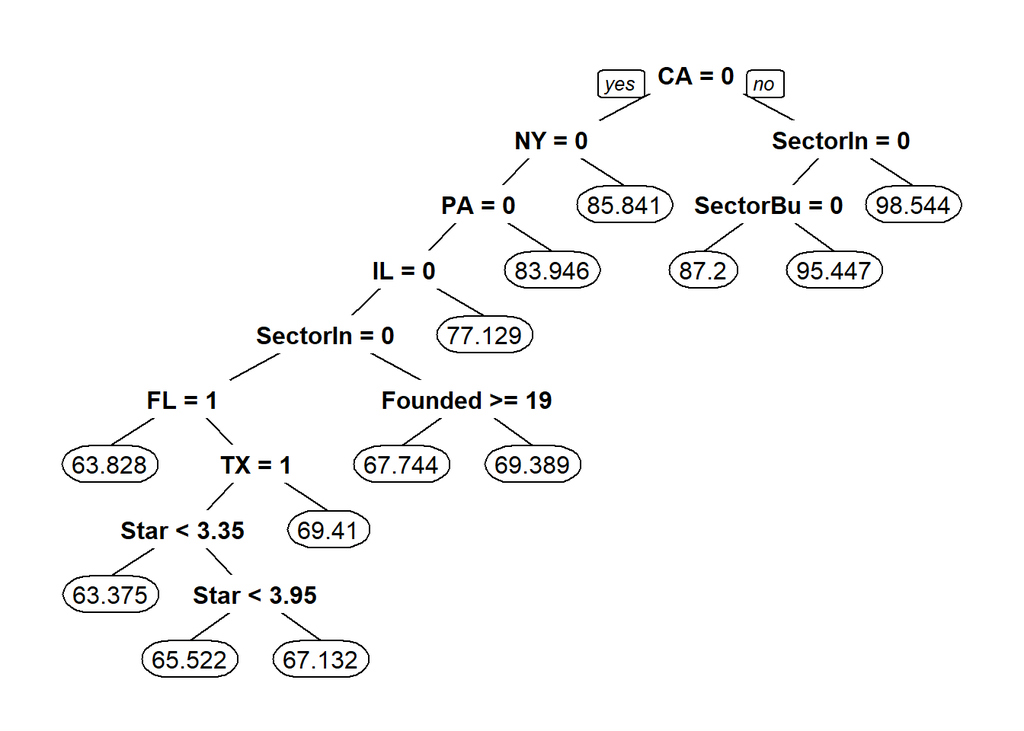

```r
tree_model <- rpart (AvgSalary ~ ., data= train_df, method='anova', minbucket=100, cp=0.00014061)
prp(tree_model,digits = -5)
```

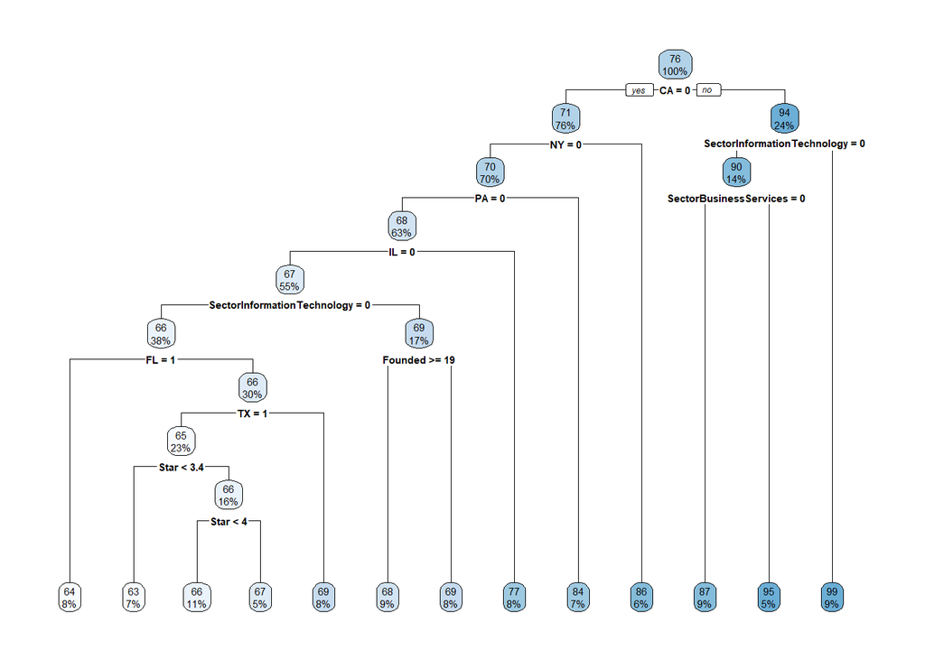

```r
rpart.plot(tree_model,digits=-2)
```

```r
pred_tree = predict(tree_model, newdata= test_df)
```

```r
SSE_tree = sum((test_df$AvgSalary - pred_tree)^2)
SST_tree = sum((test_df$AvgSalary - mean_train)^2)
OSR_tree = 1 - SSE_tree/SST_tree
print(paste("Tree Model has a OSR of", round(OSR_tree,3)))
```

```
## [1] "Tree Model has a OSR of 0.179"
```

### 3.3 Random Forest Model

```r
#there's column name that will cause trouble in xgboost model


library(randomForest)
rf_ini = randomForest(AvgSalary~.,
                      data=train_df,
                      ntree=100,
                      nodesize=50,
                      mtry=4)
```

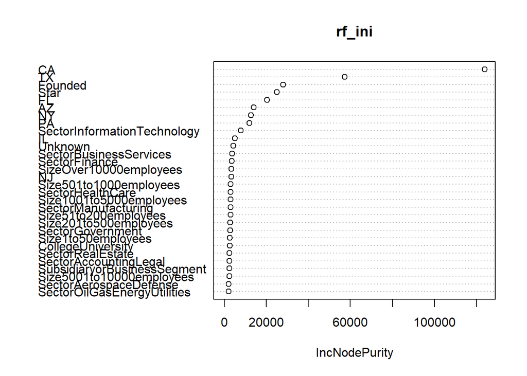

```r
varImpPlot(rf_ini)
```

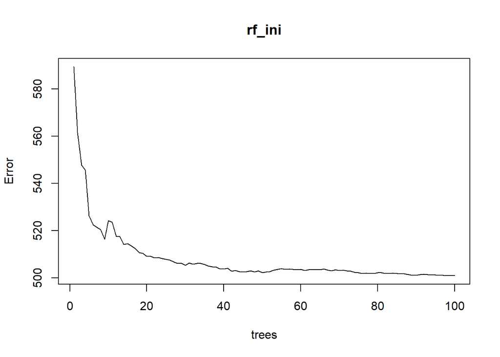

```r
plot(rf_ini)
```

```r
x = train_df[,-1]
y = train_df$AvgSalary

sqrt(ncol(x))
```

```
## [1] 6.928203
```

```r
set.seed(123, sample.kind="Rejection")
tuneRF(x, y, mtryStart = 8, stepFactor = 2, ntreeTry=100, nodesize=20, improve=0.01)
```

```
## mtry = 8  OOB error = 43.10014
## Searching left ...
## mtry = 4     OOB error = 153.7784
## -2.567934 0.01
## Searching right ...
## mtry = 16    OOB error = 7.057124
## 0.8362622 0.01
## mtry = 32    OOB error = 0.4231954
## 0.9400329 0.01
## mtry = 48    OOB error = 0.009060429
## 0.9785904 0.01
```

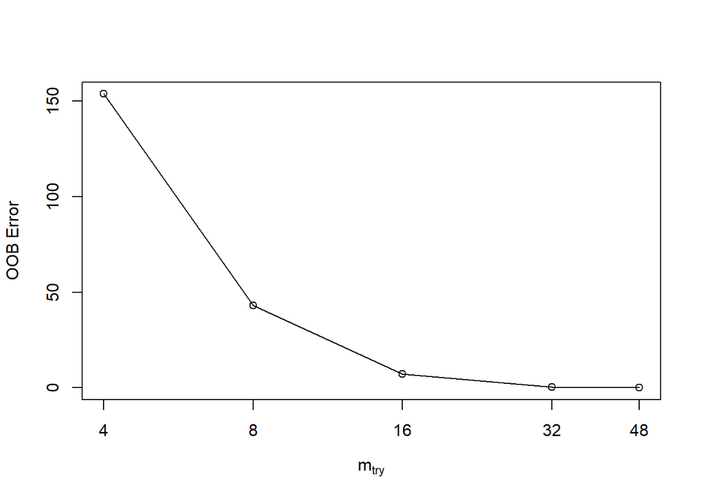

```
##    mtry     OOBError
## 4     4 1.537784e+02
## 8     8 4.310014e+01
## 16   16 7.057124e+00
## 32   32 4.231954e-01
## 48   48 9.060429e-03
```

```r
set.seed(123, sample.kind="Rejection")
rf_model = randomForest(AvgSalary~.,
                      data=train_df,
                      ntree=100,
                      nodesize=50,
                      mtry=8)
```

```r
pred_random = predict(rf_model, newdata= test_df)
# head(test_df)%>%relocate(pred_random)
SSE_random = sum((test_df$AvgSalary - pred_random )^2)
SST_random  = sum((test_df$AvgSalary - mean_train)^2)
OSR_random  = 1 - SSE_random/SST_random
print(paste("Tree Model has a OSR of", round(OSR_random ,3)))
```

```
## [1] "Tree Model has a OSR of 0.182"
```

### 3.4 XGBoosting

```r
library(caret)
set.seed(123, sample.kind = "Rejection")
xgb_model <- train(AvgSalary~., data = train_df, method = 'xgbTree',verbosity = 0) # Execution might take a very long time
```

```r
pred_xgb = predict(xgb_model, newdata= test_df)
#head(test_df)%>%relocate(pred_xgb)
SSE_xgb = sum((test_df$AvgSalary - pred_xgb)^2)
SST_xgb  = sum((test_df$AvgSalary - mean_train)^2)
OSR_xgb  = 1 - SSE_xgb/SST_xgb
print(paste("Tree Model has a OSR of", round(OSR_xgb ,3)))
```

```
## [1] "Tree Model has a OSR of 0.189"
```

```r
set.seed(123, sample.kind = "Rejection")
ctrl <- trainControl(method = "repeatedcv",
                     repeats = 5) # repeats: Repeat k-fold cross-validation.
mod_xgb <- train(AvgSalary ~ ., data = train_df,
             method = "xgbTree",
             trControl = ctrl,
             verbosity = 0)
```

```r
pred_xgb1 = predict(mod_xgb, newdata= test_df)
#head(test_df)%>%relocate(pred_xgb)
SSE_xgb1 = sum((test_df$AvgSalary - test_df$pred_xgb1)^2)
SST_xgb1  = sum((test_df$AvgSalary - mean_train)^2)
OSR_xgb1  = 1 - SSE_xgb1/SST_xgb1
print(paste("Tree Model has a OSR of", round(OSR_xgb1 ,3)))
```

```
## [1] "Tree Model has a OSR of 1"
```